# 03_gold_layer_analysis

## About the Author

This report was authored by Ayoub Majjid, a fifth-year computer engineering student at EMSI with a background in Experimental Sciences. His academic journey has provided a strong foundation in mathematics, physics, and chemistry, and has shaped a growing expertise in technology, system design, and data engineering.

Ayoub currently serves as Tech Lead and Entrepreneur at Intellcap, where he leads three innovation projects focused on building impactful and scalable startup solutions. His work emphasizes transforming ideas into robust technical systems, with a particular interest in data platforms, system architecture, and end-to-end engineering workflows.

📧 Email: ayoub@majjid.com 🌐 Website: https://majjid.com

## Copyright & Disclaimer

© 2026 **Ayoub Majjid**. All rights reserved.

This report is provided for **educational and professional demonstration purposes**. The MIMIC-III dataset remains the property of its respective owners and is used in accordance with applicable data usage agreements.

No patient-identifiable information is disclosed or altered in this document.

# 🥇 Gold Layer Analysis

This notebook analyzes the **Gold Layer** of the MIMIC-III Data Warehouse.

## What is the Gold Layer?

The Gold layer contains **analytics-ready data** organized as a dimensional model:

- **Dimension Tables**: Reference data for filtering/grouping
- **Fact Tables**: Transactional data with measures
- **Aggregate Tables**: Pre-computed summaries

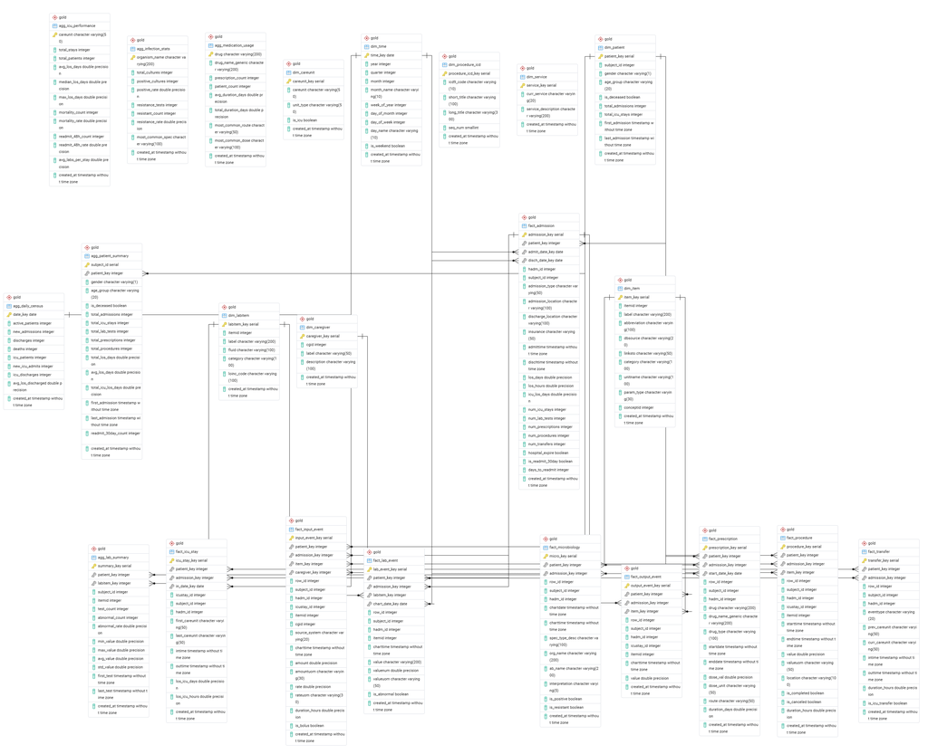

## Star Schema Design

```
                    ┌─────────────────┐
                    │   dim_patient   │
                    └────────┬────────┘
                             │
┌─────────────┐     ┌───────┴────────┐     ┌─────────────┐
│  dim_time   │─────│ fact_admission │─────│ dim_service │
└─────────────┘     └───────┬────────┘     └─────────────┘
                            │
                    ┌───────┴────────┐
                    │ fact_icu_stay  │
                    └────────────────┘
```

```python
# Setup
import sys
sys.path.insert(0, '../../..')

import pandas as pd
from sqlalchemy import text
from app.shared import get_db

pd.set_option('display.max_columns', None)
pd.set_option('display.width', None)
```

```python
# Helper functions
def query_df(sql, limit=10):
    with get_db() as session:
        result = session.execute(text(sql))
        df = pd.DataFrame(result.fetchall(), columns=result.keys())
    return df.head(limit) if limit else df

def table_count(schema, table):
    with get_db() as session:
        return session.execute(text(f"SELECT COUNT(*) FROM {schema}.{table}")).scalar()
```

# DIMENSION TABLES

Dimension tables provide the **context** for fact data - the "who, what, when, where" of analysis.

## 1. DIM_PATIENT

**Purpose**: Master patient dimension with lifetime statistics.

[output not shown]

```python
print(f"dim_patient: {table_count('gold', 'dim_patient'):,} records")
query_df("SELECT * FROM gold.dim_patient LIMIT 5")
```

```
2026-01-01 13:41:01,161 INFO sqlalchemy.engine.Engine select pg_catalog.version()
2026-01-01 13:41:01,164 INFO sqlalchemy.engine.Engine [raw sql] {}
2026-01-01 13:41:01,182 INFO sqlalchemy.engine.Engine select current_schema()
2026-01-01 13:41:01,184 INFO sqlalchemy.engine.Engine [raw sql] {}
2026-01-01 13:41:01,205 INFO sqlalchemy.engine.Engine show standard_conforming_strings
2026-01-01 13:41:01,209 INFO sqlalchemy.engine.Engine [raw sql] {}
2026-01-01 13:41:01,218 INFO sqlalchemy.engine.Engine BEGIN (implicit)
2026-01-01 13:41:01,222 INFO sqlalchemy.engine.Engine SELECT COUNT(*) FROM gold.dim_patient
2026-01-01 13:41:01,224 INFO sqlalchemy.engine.Engine [generated in 0.00206s] {}
2026-01-01 13:41:01,269 INFO sqlalchemy.engine.Engine COMMIT
dim_patient: 100 records
2026-01-01 13:41:01,281 INFO sqlalchemy.engine.Engine BEGIN (implicit)
2026-01-01 13:41:01,283 INFO sqlalchemy.engine.Engine SELECT * FROM gold.dim_patient LIMIT 5
2026-01-01 13:41:01,288 INFO sqlalchemy.engine.Engine [generated in 0.00418s] {}
2026-01-01 13:41:01,341 INFO sqlalchemy.engine.Engine COMMIT
```

|  | patient_key | subject_id | gender | age_group | is_deceased | total_admissions | total_icu_stays | first_admission | last_admission | created_at |
| --- | --- | --- | --- | --- | --- | --- | --- | --- | --- | --- |
| 0 | 4 | 10017 | F | None | True | 1 | 1 | 2149-05-26 17:19:00 | 2149-05-26 17:19:00 | 2025-12-26 00:08:42.452185 |
| 1 | 5 | 10019 | M | None | True | 1 | 1 | 2163-05-14 20:43:00 | 2163-05-14 20:43:00 | 2025-12-26 00:08:42.452185 |
| 2 | 6 | 10026 | F | None | True | 1 | 1 | 2195-05-17 07:39:00 | 2195-05-17 07:39:00 | 2025-12-26 00:08:42.452185 |
| 3 | 7 | 10027 | F | None | True | 1 | 1 | 2190-07-13 07:15:00 | 2190-07-13 07:15:00 | 2025-12-26 00:08:42.452185 |
| 4 | 8 | 10029 | M | None | True | 1 | 1 | 2139-09-22 10:58:00 | 2139-09-22 10:58:00 | 2025-12-26 00:08:42.452185 |

## 2. DIM_TIME

**Purpose**: Date dimension for time-based analysis.

| Column | Type | Description |
| --- | --- | --- |
| time_key | DATE | **PK** - Calendar date |
| year | INTEGER | Year (e.g., 2100) |
| quarter | INTEGER | Quarter (1-4) |
| month | INTEGER | Month (1-12) |
| month_name | VARCHAR | Month name |
| week_of_year | INTEGER | ISO week number |
| day_of_month | INTEGER | Day (1-31) |
| day_of_week | INTEGER | Weekday (0=Mon) |
| day_name | VARCHAR | Day name |
| is_weekend | BOOLEAN | Saturday/Sunday |

```python
print(f"dim_time: {table_count('gold', 'dim_time'):,} records")
query_df("SELECT * FROM gold.dim_time LIMIT 5")
```

```
2026-01-01 12:28:16,795 INFO sqlalchemy.engine.Engine BEGIN (implicit)
2026-01-01 12:28:16,797 INFO sqlalchemy.engine.Engine SELECT COUNT(*) FROM gold.dim_time
2026-01-01 12:28:16,798 INFO sqlalchemy.engine.Engine [generated in 0.00100s] {}
2026-01-01 12:28:16,809 INFO sqlalchemy.engine.Engine COMMIT
dim_time: 38,715 records
2026-01-01 12:28:16,813 INFO sqlalchemy.engine.Engine BEGIN (implicit)
2026-01-01 12:28:16,814 INFO sqlalchemy.engine.Engine SELECT * FROM gold.dim_time LIMIT 5
2026-01-01 12:28:16,816 INFO sqlalchemy.engine.Engine [generated in 0.00146s] {}
2026-01-01 12:28:16,823 INFO sqlalchemy.engine.Engine COMMIT
```

|  | time_key | year | quarter | month | month_name | week_of_year | day_of_month | day_of_week | day_name | is_weekend | created_at |
| --- | --- | --- | --- | --- | --- | --- | --- | --- | --- | --- | --- |
| 0 | 2100-01-01 | 2100 | 1 | 1 | January | 53 | 1 | 4 | Friday | False | 2025-12-26 00:07:01.315552 |
| 1 | 2100-01-02 | 2100 | 1 | 1 | January | 53 | 2 | 5 | Saturday | True | 2025-12-26 00:07:01.315552 |
| 2 | 2100-01-03 | 2100 | 1 | 1 | January | 53 | 3 | 6 | Sunday | True | 2025-12-26 00:07:01.315552 |
| 3 | 2100-01-04 | 2100 | 1 | 1 | January | 1 | 4 | 0 | Monday | False | 2025-12-26 00:07:01.315552 |
| 4 | 2100-01-05 | 2100 | 1 | 1 | January | 1 | 5 | 1 | Tuesday | False | 2025-12-26 00:07:01.315552 |

## 3. DIM_CAREUNIT

**Purpose**: ICU care unit dimension.

[output not shown]

```python
print(f"dim_careunit: {table_count('gold', 'dim_careunit'):,} records")
query_df("SELECT * FROM gold.dim_careunit", limit=None)
```

```
2026-01-01 12:28:41,232 INFO sqlalchemy.engine.Engine BEGIN (implicit)
2026-01-01 12:28:41,233 INFO sqlalchemy.engine.Engine SELECT COUNT(*) FROM gold.dim_careunit
2026-01-01 12:28:41,234 INFO sqlalchemy.engine.Engine [generated in 0.00060s] {}
2026-01-01 12:28:41,241 INFO sqlalchemy.engine.Engine COMMIT
dim_careunit: 5 records
2026-01-01 12:28:41,245 INFO sqlalchemy.engine.Engine BEGIN (implicit)
2026-01-01 12:28:41,246 INFO sqlalchemy.engine.Engine SELECT * FROM gold.dim_careunit
2026-01-01 12:28:41,247 INFO sqlalchemy.engine.Engine [generated in 0.00079s] {}
2026-01-01 12:28:41,251 INFO sqlalchemy.engine.Engine COMMIT
```

|  | careunit_key | careunit | unit_type | is_icu | created_at |
| --- | --- | --- | --- | --- | --- |
| 0 | 1 | MICU | ICU | True | 2025-12-26 00:08:43.702866 |
| 1 | 2 | CCU | ICU | True | 2025-12-26 00:08:43.702866 |
| 2 | 3 | TSICU | ICU | True | 2025-12-26 00:08:43.702866 |
| 3 | 4 | SICU | ICU | True | 2025-12-26 00:08:43.702866 |
| 4 | 5 | CSRU | ICU | True | 2025-12-26 00:08:43.702866 |

## 4. DIM_ITEM

**Purpose**: Item dictionary (procedures, inputs, outputs).

| Column | Type | Description |
| --- | --- | --- |
| item_key | INTEGER | **Surrogate PK** |
| itemid | INTEGER | Natural key |
| label | VARCHAR | Item name |
| abbreviation | VARCHAR | Short name |
| category | VARCHAR | Category |
| unitname | VARCHAR | Unit of measure |

```python
print(f"dim_item: {table_count('gold', 'dim_item'):,} records")
query_df("SELECT item_key, itemid, label, category FROM gold.dim_item LIMIT 10")
```

```
2026-01-01 12:28:52,295 INFO sqlalchemy.engine.Engine BEGIN (implicit)
2026-01-01 12:28:52,296 INFO sqlalchemy.engine.Engine SELECT COUNT(*) FROM gold.dim_item
2026-01-01 12:28:52,297 INFO sqlalchemy.engine.Engine [generated in 0.00095s] {}
2026-01-01 12:28:52,309 INFO sqlalchemy.engine.Engine COMMIT
dim_item: 12,487 records
2026-01-01 12:28:52,312 INFO sqlalchemy.engine.Engine BEGIN (implicit)
2026-01-01 12:28:52,313 INFO sqlalchemy.engine.Engine SELECT item_key, itemid, label, category FROM gold.dim_item LIMIT 10
2026-01-01 12:28:52,314 INFO sqlalchemy.engine.Engine [generated in 0.00103s] {}
2026-01-01 12:28:52,320 INFO sqlalchemy.engine.Engine COMMIT
```

|  | item_key | itemid | label | category |
| --- | --- | --- | --- | --- |
| 0 | 1 | 1435 | Sustained Nystamus | None |
| 1 | 2 | 1436 | Tactile Disturbances | None |
| 2 | 3 | 1437 | Tremor | None |
| 3 | 4 | 1438 | Ulnar Pulse [Right] | None |
| 4 | 5 | 1439 | Visual Disturbances | None |
| 5 | 6 | 1447 | Transpulmonary Pres | None |
| 6 | 7 | 1448 | Vd/Vt: | None |
| 7 | 8 | 1449 | Arterial BP(Rad) | None |
| 8 | 9 | 1450 | level one | None |
| 9 | 10 | 1451 | L girth size | None |

## 5. DIM_LABITEM

**Purpose**: Lab test dictionary.

| Column | Type | Description |
| --- | --- | --- |
| labitem_key | INTEGER | **Surrogate PK** |
| itemid | INTEGER | Natural key |
| label | VARCHAR | Test name |
| fluid | VARCHAR | Specimen type |
| category | VARCHAR | Test category |
| loinc_code | VARCHAR | LOINC code |

```python
print(f"dim_labitem: {table_count('gold', 'dim_labitem'):,} records")
query_df("SELECT labitem_key, itemid, label, fluid, category FROM gold.dim_labitem LIMIT 10")
```

```
2026-01-01 12:29:04,463 INFO sqlalchemy.engine.Engine BEGIN (implicit)
2026-01-01 12:29:04,464 INFO sqlalchemy.engine.Engine SELECT COUNT(*) FROM gold.dim_labitem
2026-01-01 12:29:04,465 INFO sqlalchemy.engine.Engine [generated in 0.00103s] {}
2026-01-01 12:29:04,473 INFO sqlalchemy.engine.Engine COMMIT
dim_labitem: 753 records
2026-01-01 12:29:04,477 INFO sqlalchemy.engine.Engine BEGIN (implicit)
2026-01-01 12:29:04,477 INFO sqlalchemy.engine.Engine SELECT labitem_key, itemid, label, fluid, category FROM gold.dim_labitem LIMIT 10
2026-01-01 12:29:04,478 INFO sqlalchemy.engine.Engine [generated in 0.00056s] {}
2026-01-01 12:29:04,481 INFO sqlalchemy.engine.Engine COMMIT
```

|  | labitem_key | itemid | label | fluid | category |
| --- | --- | --- | --- | --- | --- |
| 0 | 1 | 50800 | SPECIMEN TYPE | BLOOD | BLOOD GAS |
| 1 | 2 | 50801 | Alveolar-arterial Gradient | Blood | Blood Gas |
| 2 | 3 | 50802 | Base Excess | Blood | Blood Gas |
| 3 | 4 | 50803 | Calculated Bicarbonate, Whole Blood | Blood | Blood Gas |
| 4 | 5 | 50804 | Calculated Total CO2 | Blood | Blood Gas |
| 5 | 6 | 50805 | Carboxyhemoglobin | Blood | Blood Gas |
| 6 | 7 | 50806 | Chloride, Whole Blood | Blood | Blood Gas |
| 7 | 8 | 50807 | Comments | Blood | Blood Gas |
| 8 | 9 | 50808 | Free Calcium | Blood | Blood Gas |
| 9 | 10 | 50809 | Glucose | Blood | Blood Gas |

# FACT TABLES

Fact tables contain the **measurable events** - admissions, lab tests, prescriptions, etc.

## 6. FACT_ADMISSION

**Purpose**: Hospital admissions with enriched metrics.

| Column | Type | Description |
| --- | --- | --- |
| admission_key | INTEGER | **Surrogate PK** |
| hadm_id | INTEGER | **NK** - Admission ID |
| patient_key | INTEGER | FK to dim_patient |
| admit_date_key | DATE | FK to dim_time |
| disch_date_key | DATE | FK to dim_time |
| admission_type | VARCHAR | EMERGENCY, ELECTIVE, etc. |
| los_days | FLOAT | Length of stay (days) |
| los_hours | FLOAT | Length of stay (hours) |
| num_icu_stays | INTEGER | **Aggregated** ICU stays |
| num_lab_tests | INTEGER | **Aggregated** lab tests |
| num_prescriptions | INTEGER | **Aggregated** prescriptions |
| hospital_expire | BOOLEAN | Died in hospital |

```python
print(f"fact_admission: {table_count('gold', 'fact_admission'):,} records")
query_df("""
    SELECT hadm_id, admission_type, los_days,
           num_icu_stays, num_lab_tests, num_prescriptions, hospital_expire
    FROM gold.fact_admission
    ORDER BY num_lab_tests DESC
    LIMIT 5
""")
```

```
2026-01-01 12:29:17,174 INFO sqlalchemy.engine.Engine BEGIN (implicit)
2026-01-01 12:29:17,175 INFO sqlalchemy.engine.Engine SELECT COUNT(*) FROM gold.fact_admission
2026-01-01 12:29:17,177 INFO sqlalchemy.engine.Engine [generated in 0.00133s] {}
2026-01-01 12:29:17,186 INFO sqlalchemy.engine.Engine COMMIT
fact_admission: 129 records
2026-01-01 12:29:17,190 INFO sqlalchemy.engine.Engine BEGIN (implicit)
2026-01-01 12:29:17,191 INFO sqlalchemy.engine.Engine
    SELECT hadm_id, admission_type, los_days,
           num_icu_stays, num_lab_tests, num_prescriptions, hospital_expire
    FROM gold.fact_admission
    ORDER BY num_lab_tests DESC
    LIMIT 5

2026-01-01 12:29:17,192 INFO sqlalchemy.engine.Engine [generated in 0.00075s] {}
2026-01-01 12:29:17,198 INFO sqlalchemy.engine.Engine COMMIT
```

|  | hadm_id | admission_type | los_days | num_icu_stays | num_lab_tests | num_prescriptions | hospital_expire |
| --- | --- | --- | --- | --- | --- | --- | --- |
| 0 | 186361 | EMERGENCY | 123.98 | 1 | 6880 | 784 | False |
| 1 | 160445 | EMERGENCY | 35.25 | 1 | 4967 | 437 | True |
| 2 | 163189 | EMERGENCY | 36.01 | 1 | 3093 | 209 | False |
| 3 | 145203 | EMERGENCY | 25.00 | 1 | 1841 | 314 | False |
| 4 | 170883 | EMERGENCY | 28.94 | 3 | 1478 | 244 | True |

```python
# Admission analysis with dimensions
query_df("""
    SELECT
        fa.admission_type,
        COUNT(*) as admissions,
        ROUND(AVG(fa.los_days)::numeric, 2) AS avg_los,
        SUM(fa.num_icu_stays) as total_icu_stays,
        SUM(fa.num_lab_tests) as total_labs
    FROM gold.fact_admission fa
    GROUP BY fa.admission_type
    ORDER BY admissions DESC
""", limit=None)
```

```
2026-01-01 12:31:31,561 INFO sqlalchemy.engine.Engine BEGIN (implicit)
2026-01-01 12:31:31,562 INFO sqlalchemy.engine.Engine
    SELECT
        fa.admission_type,
        COUNT(*) as admissions,
        ROUND(AVG(fa.los_days)::numeric, 2) AS avg_los,
        SUM(fa.num_icu_stays) as total_icu_stays,
        SUM(fa.num_lab_tests) as total_labs
    FROM gold.fact_admission fa
    GROUP BY fa.admission_type
    ORDER BY admissions DESC

2026-01-01 12:31:31,563 INFO sqlalchemy.engine.Engine [generated in 0.00103s] {}
2026-01-01 12:31:31,572 INFO sqlalchemy.engine.Engine COMMIT
```

|  | admission_type | admissions | avg_los | total_icu_stays | total_labs |
| --- | --- | --- | --- | --- | --- |
| 0 | EMERGENCY | 119 | 9.23 | 126 | 58159 |
| 1 | ELECTIVE | 8 | 11.67 | 8 | 3139 |
| 2 | URGENT | 2 | 6.26 | 2 | 514 |

## 7. FACT_ICU_STAY

**Purpose**: ICU stay facts with dimensional keys.

| Column | Type | Description |
| --- | --- | --- |
| icu_stay_key | INTEGER | **Surrogate PK** |
| icustay_id | INTEGER | **NK** - ICU stay ID |
| patient_key | INTEGER | FK to dim_patient |
| in_date_key | DATE | FK to dim_time |
| first_careunit | VARCHAR | First ICU unit |
| last_careunit | VARCHAR | Last ICU unit |
| los_icu_days | FLOAT | ICU length of stay |
| los_icu_hours | FLOAT | ICU LOS (hours) |

```python
print(f"fact_icu_stay: {table_count('gold', 'fact_icu_stay'):,} records")
query_df("""
    SELECT icustay_id, first_careunit, last_careunit, los_icu_days, los_icu_hours
    FROM gold.fact_icu_stay
    ORDER BY los_icu_days DESC
    LIMIT 5
""")
```

```
2026-01-01 12:31:42,520 INFO sqlalchemy.engine.Engine BEGIN (implicit)
2026-01-01 12:31:42,521 INFO sqlalchemy.engine.Engine SELECT COUNT(*) FROM gold.fact_icu_stay
2026-01-01 12:31:42,523 INFO sqlalchemy.engine.Engine [generated in 0.00126s] {}
2026-01-01 12:31:42,534 INFO sqlalchemy.engine.Engine COMMIT
fact_icu_stay: 136 records
2026-01-01 12:31:42,538 INFO sqlalchemy.engine.Engine BEGIN (implicit)
2026-01-01 12:31:42,540 INFO sqlalchemy.engine.Engine
    SELECT icustay_id, first_careunit, last_careunit, los_icu_days, los_icu_hours
    FROM gold.fact_icu_stay
    ORDER BY los_icu_days DESC
    LIMIT 5

2026-01-01 12:31:42,541 INFO sqlalchemy.engine.Engine [generated in 0.00093s] {}
2026-01-01 12:31:42,545 INFO sqlalchemy.engine.Engine COMMIT
```

|  | icustay_id | first_careunit | last_careunit | los_icu_days | los_icu_hours |
| --- | --- | --- | --- | --- | --- |
| 0 | 249805 | SICU | SICU | 35.41 | 849.76 |
| 1 | 239396 | MICU | MICU | 31.12 | 746.96 |
| 2 | 250305 | SICU | SICU | 29.26 | 702.24 |
| 3 | 223177 | CCU | CCU | 25.00 | 599.92 |
| 4 | 271544 | TSICU | TSICU | 22.39 | 537.35 |

## 8. FACT_LAB_EVENT

**Purpose**: Lab test results with dimension keys.

| Column | Type | Description |
| --- | --- | --- |
| lab_event_key | INTEGER | **Surrogate PK** |
| row_id | INTEGER | Original row ID |
| patient_key | INTEGER | FK to dim_patient |
| labitem_key | INTEGER | FK to dim_labitem |
| chart_date_key | DATE | FK to dim_time |
| valuenum | FLOAT | Numeric result |
| valueuom | VARCHAR | Unit of measure |
| is_abnormal | BOOLEAN | Abnormal flag |

```python
print(f"fact_lab_event: {table_count('gold', 'fact_lab_event'):,} records")
query_df("""
    SELECT row_id, itemid, charttime, valuenum, valueuom, is_abnormal
    FROM gold.fact_lab_event
    WHERE valuenum IS NOT NULL
    LIMIT 5
""")
```

[output not shown]

|  | row_id | itemid | charttime | valuenum | valueuom | is_abnormal |
| --- | --- | --- | --- | --- | --- | --- |
| 0 | 6245566 | 50912 | 2164-11-16 05:50:00 | 2.1 | mg/dL | True |
| 1 | 6245567 | 50931 | 2164-11-16 05:50:00 | 162.0 | mg/dL | True |
| 2 | 6245568 | 50960 | 2164-11-16 05:50:00 | 1.0 | mg/dL | True |
| 3 | 6245569 | 50970 | 2164-11-16 05:50:00 | 3.6 | mg/dL | False |
| 4 | 6245570 | 50971 | 2164-11-16 05:50:00 | 2.6 | mEq/L | True |

```python
# Lab analysis with dimension join
query_df("""
    SELECT
        dl.label as test_name,
        dl.fluid,
        COUNT(*) as test_count,
        SUM(CASE WHEN fl.is_abnormal THEN 1 ELSE 0 END) as abnormal_count,
        ROUND(100.0 * SUM(CASE WHEN fl.is_abnormal THEN 1 ELSE 0 END) / COUNT(*), 1) as abnormal_pct
    FROM gold.fact_lab_event fl
    JOIN gold.dim_labitem dl ON fl.labitem_key = dl.labitem_key
    GROUP BY dl.label, dl.fluid
    ORDER BY test_count DESC
    LIMIT 10
""")
```

```
2026-01-01 12:32:03,507 INFO sqlalchemy.engine.Engine BEGIN (implicit)
2026-01-01 12:32:03,508 INFO sqlalchemy.engine.Engine
    SELECT
        dl.label as test_name,
        dl.fluid,
        COUNT(*) as test_count,
        SUM(CASE WHEN fl.is_abnormal THEN 1 ELSE 0 END) as abnormal_count,
        ROUND(100.0 * SUM(CASE WHEN fl.is_abnormal THEN 1 ELSE 0 END) / COUNT(*), 1) as abnormal_pct
    FROM gold.fact_lab_event fl
    JOIN gold.dim_labitem dl ON fl.labitem_key = dl.labitem_key
    GROUP BY dl.label, dl.fluid
    ORDER BY test_count DESC
    LIMIT 10

2026-01-01 12:32:03,509 INFO sqlalchemy.engine.Engine [generated in 0.00058s] {}
2026-01-01 12:32:03,569 INFO sqlalchemy.engine.Engine COMMIT
```

|  | test_name | fluid | test_count | abnormal_count | abnormal_pct |
| --- | --- | --- | --- | --- | --- |
| 0 | Glucose | Blood | 2404 | 1719 | 71.5 |
| 1 | Hematocrit | Blood | 2317 | 2192 | 94.6 |
| 2 | Potassium | Blood | 2279 | 279 | 12.2 |
| 3 | Sodium | Blood | 2185 | 471 | 21.6 |
| 4 | Creatinine | Blood | 2175 | 1025 | 47.1 |
| 5 | Chloride | Blood | 2160 | 715 | 33.1 |
| 6 | Urea Nitrogen | Blood | 2158 | 1262 | 58.5 |
| 7 | Bicarbonate | Blood | 2151 | 638 | 29.7 |
| 8 | Hemoglobin | Blood | 2150 | 2039 | 94.8 |
| 9 | Anion Gap | Blood | 2134 | 140 | 6.6 |

# AGGREGATE TABLES

Pre-computed summaries for fast dashboard queries.

## 9. AGG_PATIENT_SUMMARY

**Purpose**: Per-patient lifetime statistics.

| Column | Type | Description |
| --- | --- | --- |
| subject_id | INTEGER | **PK** - Patient ID |
| total_admissions | INTEGER | Lifetime admission count |
| total_icu_stays | INTEGER | Lifetime ICU count |
| total_lab_tests | INTEGER | Lifetime lab count |
| total_prescriptions | INTEGER | Lifetime prescriptions |
| total_los_days | FLOAT | Total days in hospital |

```python
print(f"agg_patient_summary: {table_count('gold', 'agg_patient_summary'):,} records")
query_df("""
    SELECT subject_id, total_admissions, total_icu_stays,
           total_lab_tests, total_prescriptions, total_los_days
    FROM gold.agg_patient_summary
    ORDER BY total_lab_tests DESC
    LIMIT 5
""")
```

```
2026-01-01 12:32:39,062 INFO sqlalchemy.engine.Engine BEGIN (implicit)
2026-01-01 12:32:39,063 INFO sqlalchemy.engine.Engine SELECT COUNT(*) FROM gold.agg_patient_summary
2026-01-01 12:32:39,063 INFO sqlalchemy.engine.Engine [generated in 0.00063s] {}
2026-01-01 12:32:39,072 INFO sqlalchemy.engine.Engine COMMIT
agg_patient_summary: 100 records
2026-01-01 12:32:39,076 INFO sqlalchemy.engine.Engine BEGIN (implicit)
2026-01-01 12:32:39,077 INFO sqlalchemy.engine.Engine
    SELECT subject_id, total_admissions, total_icu_stays,
           total_lab_tests, total_prescriptions, total_los_days
    FROM gold.agg_patient_summary
    ORDER BY total_lab_tests DESC
    LIMIT 5

2026-01-01 12:32:39,078 INFO sqlalchemy.engine.Engine [generated in 0.00103s] {}
2026-01-01 12:32:39,082 INFO sqlalchemy.engine.Engine COMMIT
```

|  | subject_id | total_admissions | total_icu_stays | total_lab_tests | total_prescriptions | total_los_days |
| --- | --- | --- | --- | --- | --- | --- |
| 0 | 40310 | 2 | 2 | 7262 | 893 | 131.00 |
| 1 | 10126 | 1 | 1 | 5009 | 437 | 35.25 |
| 2 | 41976 | 15 | 15 | 4495 | 1158 | 84.40 |
| 3 | 44212 | 1 | 1 | 3093 | 209 | 36.01 |
| 4 | 42135 | 2 | 2 | 2522 | 282 | 33.69 |

## 10. AGG_ICU_PERFORMANCE

**Purpose**: ICU unit performance metrics.

| Column | Type | Description |
| --- | --- | --- |
| careunit | VARCHAR | **PK** - ICU unit |
| total_stays | INTEGER | Total ICU stays |
| total_patients | INTEGER | Unique patients |
| avg_los_days | FLOAT | Average LOS |
| max_los_days | FLOAT | Maximum LOS |

```python
print(f"agg_icu_performance: {table_count('gold', 'agg_icu_performance'):,} records")
query_df("SELECT * FROM gold.agg_icu_performance ORDER BY total_stays DESC", limit=None)
```

```
2026-01-01 12:32:55,565 INFO sqlalchemy.engine.Engine BEGIN (implicit)
2026-01-01 12:32:55,566 INFO sqlalchemy.engine.Engine SELECT COUNT(*) FROM gold.agg_icu_performance
2026-01-01 12:32:55,567 INFO sqlalchemy.engine.Engine [generated in 0.00086s] {}
2026-01-01 12:32:55,573 INFO sqlalchemy.engine.Engine COMMIT
agg_icu_performance: 5 records
2026-01-01 12:32:55,577 INFO sqlalchemy.engine.Engine BEGIN (implicit)
2026-01-01 12:32:55,579 INFO sqlalchemy.engine.Engine SELECT * FROM gold.agg_icu_performance ORDER BY total_stays DESC
2026-01-01 12:32:55,580 INFO sqlalchemy.engine.Engine [generated in 0.00092s] {}
2026-01-01 12:32:55,584 INFO sqlalchemy.engine.Engine COMMIT
```

|  | careunit | total_stays | total_patients | avg_los_days | median_los_days | max_los_days | mortality_count | mortality_rate | readmit_48h_count | readmit_48h_rate | avg_labs_per_stay | created_at |
| --- | --- | --- | --- | --- | --- | --- | --- | --- | --- | --- | --- | --- |
| 0 | MICU | 77 | 56 | 3.955455 | None | 31.12 | 0 | None | 0 | None | None | 2025-12-26 00:09:07.320716 |
| 1 | SICU | 23 | 20 | 5.669130 | None | 35.41 | 0 | None | 0 | None | None | 2025-12-26 00:09:07.320716 |
| 2 | CCU | 19 | 18 | 5.753684 | None | 25.00 | 0 | None | 0 | None | None | 2025-12-26 00:09:07.320716 |
| 3 | TSICU | 11 | 11 | 3.590909 | None | 22.39 | 0 | None | 0 | None | None | 2025-12-26 00:09:07.320716 |
| 4 | CSRU | 6 | 6 | 3.631667 | None | 8.14 | 0 | None | 0 | None | None | 2025-12-26 00:09:07.320716 |

## 11. AGG_MEDICATION_USAGE

**Purpose**: Drug usage statistics.

| Column | Type | Description |
| --- | --- | --- |
| drug | VARCHAR | **PK** - Drug name |
| prescription_count | INTEGER | Total prescriptions |
| patient_count | INTEGER | Unique patients |

```python
print(f"agg_medication_usage: {table_count('gold', 'agg_medication_usage'):,} records")
query_df("""
    SELECT drug, prescription_count, patient_count
    FROM gold.agg_medication_usage
    ORDER BY prescription_count DESC
    LIMIT 10
""")
```

[output not shown]

## 12. AGG_INFECTION_STATS

**Purpose**: Infection/organism statistics.

| Column | Type | Description |
| --- | --- | --- |
| organism_name | VARCHAR | **PK** - Organism |
| total_cultures | INTEGER | Culture count |
| positive_cultures | INTEGER | Positive count |
| resistant_count | INTEGER | Resistant cultures |

```python
print(f"agg_infection_stats: {table_count('gold', 'agg_infection_stats'):,} records")
query_df("""
    SELECT organism_name, total_cultures, positive_cultures, resistant_count
    FROM gold.agg_infection_stats
    ORDER BY total_cultures DESC
    LIMIT 10
""")
```

```
2026-01-01 12:33:10,665 INFO sqlalchemy.engine.Engine BEGIN (implicit)
2026-01-01 12:33:10,666 INFO sqlalchemy.engine.Engine SELECT COUNT(*) FROM gold.agg_infection_stats
2026-01-01 12:33:10,667 INFO sqlalchemy.engine.Engine [generated in 0.00107s] {}
2026-01-01 12:33:10,671 INFO sqlalchemy.engine.Engine COMMIT
agg_infection_stats: 46 records
2026-01-01 12:33:10,673 INFO sqlalchemy.engine.Engine BEGIN (implicit)
2026-01-01 12:33:10,674 INFO sqlalchemy.engine.Engine
    SELECT organism_name, total_cultures, positive_cultures, resistant_count
    FROM gold.agg_infection_stats
    ORDER BY total_cultures DESC
    LIMIT 10

2026-01-01 12:33:10,675 INFO sqlalchemy.engine.Engine [generated in 0.00058s] {}
2026-01-01 12:33:10,678 INFO sqlalchemy.engine.Engine COMMIT
```

|  | organism_name | total_cultures | positive_cultures | resistant_count |
| --- | --- | --- | --- | --- |
| 0 | ESCHERICHIA COLI | 234 | 234 | 32 |
| 1 | STAPH AUREUS COAG + | 172 | 172 | 68 |
| 2 | PROTEUS MIRABILIS | 107 | 107 | 43 |
| 3 | KLEBSIELLA PNEUMONIAE | 101 | 101 | 23 |
| 4 | PSEUDOMONAS AERUGINOSA | 98 | 98 | 31 |
| 5 | ACINETOBACTER BAUMANNII COMPLEX | 58 | 58 | 11 |
| 6 | STAPHYLOCOCCUS, COAGULASE NEGATIVE | 53 | 53 | 22 |
| 7 | YEAST | 44 | 44 | 0 |
| 8 | SERRATIA MARCESCENS | 31 | 31 | 7 |
| 9 | ENTEROCOCCUS SP. | 27 | 27 | 13 |

# Gold Layer Summary

```python
# Complete Gold layer summary
gold_tables = {
    'Dimensions': ['dim_patient', 'dim_time', 'dim_careunit', 'dim_item', 'dim_labitem',
                   'dim_service', 'dim_procedure_icd', 'dim_caregiver'],
    'Facts': ['fact_admission', 'fact_icu_stay', 'fact_lab_event', 'fact_prescription',
              'fact_transfer', 'fact_input_event', 'fact_output_event',
              'fact_procedure', 'fact_microbiology'],
    'Aggregates': ['agg_patient_summary', 'agg_daily_census', 'agg_icu_performance',
                   'agg_lab_summary', 'agg_medication_usage', 'agg_infection_stats']
}

summary = []
for category, tables in gold_tables.items():
    for table in tables:
        try:
            count = table_count('gold', table)
            summary.append({'category': category, 'table': table, 'count': count})
        except:
            summary.append({'category': category, 'table': table, 'count': 'N/A'})

pd.DataFrame(summary)
```

[output not shown]

[output cut: 37 more lines]

[output not shown]

|  | category | table | count |
| --- | --- | --- | --- |
| 0 | Dimensions | dim_patient | 100 |
| 1 | Dimensions | dim_time | 38715 |
| 2 | Dimensions | dim_careunit | 5 |
| 3 | Dimensions | dim_item | 12487 |
| 4 | Dimensions | dim_labitem | 753 |
| 5 | Dimensions | dim_service | 3 |
| 6 | Dimensions | dim_procedure_icd | 64 |
| 7 | Dimensions | dim_caregiver | 7567 |
| 8 | Facts | fact_admission | 129 |
| 9 | Facts | fact_icu_stay | 136 |
| 10 | Facts | fact_lab_event | 228222 |
| 11 | Facts | fact_prescription | 31194 |
| 12 | Facts | fact_transfer | 1572 |
| 13 | Facts | fact_input_event | 48023 |
| 14 | Facts | fact_output_event | 22640 |
| 15 | Facts | fact_procedure | 1506 |
| 16 | Facts | fact_microbiology | 4006 |
| 17 | Aggregates | agg_patient_summary | 100 |
| 18 | Aggregates | agg_daily_census | 129 |
| 19 | Aggregates | agg_icu_performance | 5 |
| 20 | Aggregates | agg_lab_summary | 18530 |
| 21 | Aggregates | agg_medication_usage | 590 |
| 22 | Aggregates | agg_infection_stats | 46 |